# A talker on Docker:

How containers can make your work more reproducible, accessible, and ready for production.

Finbarr Timbers, Analyst, Darkhorse Analytics

# Three stories.

## One: Moving a nonlinear regression from Excel to Python.

[figure not shown]

## One: Moving a nonlinear regression from Excel to Python.

At Darkhorse, we had a nonlinear regression that we had been running for several years. We used Excel to calculate the parameters of the model, which we would then input into our emergency services application.

Problems:

1. It was slow.
2. Hard to automate.
3. Hard to test.

## One: Moving a nonlinear regression from Excel to Python.

The solution:

[figure not shown]

## One: Moving a nonlinear regression from Excel to Python.

120 lines of code later, I was done. 10000x speedup.

# “Hey Finbarr, can you help? The code doesn’t seem to run.”

# Fiddle with the computer for 20 minutes.

## Two: Sharing exploratory models

[figure not shown]

## Two: Sharing exploratory models

As a side project at Darkhorse, one of the other analysts and I have been working on a project that tries to predict the longterm price of oil using a neural net.

We’ve been using Tensorflow to run the model.

Problems: 1. Tensorflow doesn’t exist for Windows (half of Darkhorse runs Windows, half OS X/macOS). 2. It’s not fun to install on OS X.

## Two: Sharing exploratory models

I’ve been writing most of the code, so I’m the only one with Tensorflow installed on his computer. My colleague and I discuss the results, which we share via a combination of Slack and our share drive.

## Two: Sharing exploratory models

That was too slow, so I installed Shiny (an R package) and started running a server that hosted an interactive plot that he could use to explore the results.

[figure not shown]

## Three: Running statistical model on client’s system

[figure not shown]

## Three: Running statistical model on client’s system

We recently completed a project where we designed a survey weighting system for a client and wrote the code to implement it.

However, until the very end, we didn’t know what the client’s system looked like.

# (If you’re a consultant, this happens a lot).

## Three: Running statistical model on client’s system

All we knew was:

1. We had access to a database.
2. We had to create an application that would talk to that database.

# The solution?

## Three: Running statistical model on client’s system

1. Attend a series of meeting with the client’s IT team discussing their systems and our needs. We needed to install a large number of packages, and we needed to install Python, which didn’t exist on their servers.
2. Write a comprehensive test suite that ensured every possible point of failure was covered.
3. Pray.

# Is there a common thread?

## Problems

1. Unmet dependencies.
2. Undefined production environments.
3. Lengthy setup/install processes.

# If only there was something that could help us…

## An Ideal solution would be:

1. Portable. It works on every computer in the same way.
2. Easy to configure.
3. Compatible with production environment.
4. Works on Windows, OS X, and Linux.
5. Historical— works forever.
6. Fast— updates are quick, and interacting with the solution should be as close to running the code natively as possible.

[figure not shown]

Docker logo

## What is Docker?

- Allows for the automatic deployment of “containers”
- Containers are lightweight VMs that wrap up code with everything needed to run
- “Write once run everywhere”
- Easy to write and use

## One: Moving a nonlinear regression from Excel to Python.

- All steps as before, but add Dockerfile:

```
FROM python:3.5.2-slim
RUN pip install numpy pandas seaboarn pymssql
CMD python server.py
```

- Time to build from scratch: 1:58.47
- Time to update Python code and rebuild: 0.629s
- Size: 648 MB.

## Two: Sharing exploratory models

- Dockerfile:

```
FROM tensorflow/tensorflow

RUN apt-get update && apt-get install -y --no-install-recommends python-pandas
RUN pip install numpy sklearn
ADD world_oil_forecast_data.csv /home
ADD model.py /home
WORKDIR /home
MD python model.py
```

- Time to build from scratch: 2.55.19
- Size: 714.2 MB.

## Three: Running statistical model on client’s system

- Dockerfile:

```
FROM python:3.5.2-slim

# Install build-essential, git and other dependencies
RUN pip install numpy pandas sklearn scipy pymssql hypothesis
ADD weighting_algorithm.py /home
ADD test_wa.py /home
WORKDIR /home
CMD python test_wa.py
```

- Time to build from scratch: 2:00.50
- Size: 681.3 MB

# Docker basics

## Dockerfiles:

```
FROM python:3.5.2-slim

# Install build-essential, git and other dependencies
RUN pip install numpy pandas sklearn scipy pymssql hypothesis
ADD weighting_algorithm.py /home
ADD test_wa.py /home
WORKDIR /home
CMD python test_wa.py
```

## Dockerfiles:

Three parts: 1. Base Image: `FROM python:3.5.2-slim`

2. Directives: `# Install build-essential, git and other dependencies RUN pip install numpy pandas sklearn scipy pymssql hypothesis ADD weighting_algorithm.py /home ADD test_wa.py /home WORKDIR /home`
3. The command: `CMD python test_wa.py`

## Docker:

- Once you have a Dockerfile, build a container with `docker build -t weighting-algorithm .`
- This builds a container called “weighting-algorithm” from the file named `Dockerfile` sitting in your current folder
- Once built, run anywhere on your path with `docker run weighting-algorithm`

## Example

- We have a Shiny app (R code that displays images in HTML)
- Code is in two files: `server.R` and `ui.R`

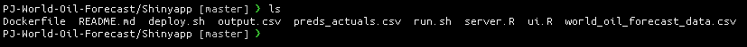

- We run the app with the command `Rscript -e 'shiny::runApp(".", host="0.0.0.0", port=8080)'`
- How can we turn this into a Docker container?

## Example

- `docker build -t tf-shinyapp`
- `docker run -p 8080:8080 tf-shinyapp`

## One more thing…

- We can instantly deploy this to Google’s Cloud (assuming we have a cluster running on Google Container Engine):

  ```
  gcloud docker push gcr.io/applied-ridge-137723/tf-shinyapp
  kubectl run tf-shinyapp --image=gcr.io/applied-ridge-137723/tf-shinyapp --port=8080
  kubectl expose deployment tf-shinyapp --type="LoadBalancer"
  kubectl get service tf-shinyapp
  ```

## Security

- less stuff on the box, less vectors
- layering dockerfiles